# Exploring Employee Exit Surveys

# Intro.

The purpose of this analyses is to discover potential patterns regarding employee's who have terminated their employment at The Department of Education, Training and Employment (DETE) and the Technical and Further Education (TAFE) insititute in Queensland, Austrlia. The insights will be used as a basis for further analyses as well as for potential recommendations for improvements to reduce employee turnover for the two institutes. For this analyses, we will be using the employee exist survey's released by the insititutes, which can be found here (TAFE) and here (DETE).

The analyses as hypothetically requested by the institutes will be mainly focused on dissatisfaction as a factor of employee turnover. As such, we'll attempt to answer the following questions:

- Are employees who only worked for the institutes for a short period of time resigning due to some kind of dissatisfaction?
- Are younger employees resigning due to some kind of dissatisfaction?
- How does dissatisfaction compare between the two institutions?

## Packages Used

```python
import pandas as pd
import numpy as np

from matplotlib import pyplot as plt
import seaborn as sns
import plotly.offline as pyo
pyo.init_notebook_mode()
import plotly.express as px
```

## 1. Initial Preprocessing and Data Overview

Let's start by loading and getting a quick overview of the datasets by printing out the top 5 rows, and their corresponding shape.

```python
df1 = pd.read_csv('dete_survey.csv')
df2 = pd.read_csv('tafe_survey.csv')
```

```python
print(df1.shape) #tuple of row and columns of dataframe
df1.head() #prints top 5 rows
```

```
(822, 56)
```

|  | ID | SeparationType | Cease Date | DETE Start Date | Role Start Date | Position | Classification | Region | Business Unit | Employment Status | ... | Kept informed | Wellness programs | Health & Safety | Gender | Age | Aboriginal | Torres Strait | South Sea | Disability | NESB |
| --- | --- | --- | --- | --- | --- | --- | --- | --- | --- | --- | --- | --- | --- | --- | --- | --- | --- | --- | --- | --- | --- |
| 0 | 1 | Ill Health Retirement | 08/2012 | 1984 | 2004 | Public Servant | A01-A04 | Central Office | Corporate Strategy and Peformance | Permanent Full-time | ... | N | N | N | Male | 56-60 | NaN | NaN | NaN | NaN | Yes |
| 1 | 2 | Voluntary Early Retirement (VER) | 08/2012 | Not Stated | Not Stated | Public Servant | AO5-AO7 | Central Office | Corporate Strategy and Peformance | Permanent Full-time | ... | N | N | N | Male | 56-60 | NaN | NaN | NaN | NaN | NaN |
| 2 | 3 | Voluntary Early Retirement (VER) | 05/2012 | 2011 | 2011 | Schools Officer | NaN | Central Office | Education Queensland | Permanent Full-time | ... | N | N | N | Male | 61 or older | NaN | NaN | NaN | NaN | NaN |
| 3 | 4 | Resignation-Other reasons | 05/2012 | 2005 | 2006 | Teacher | Primary | Central Queensland | NaN | Permanent Full-time | ... | A | N | A | Female | 36-40 | NaN | NaN | NaN | NaN | NaN |
| 4 | 5 | Age Retirement | 05/2012 | 1970 | 1989 | Head of Curriculum/Head of Special Education | NaN | South East | NaN | Permanent Full-time | ... | N | A | M | Female | 61 or older | NaN | NaN | NaN | NaN | NaN |

5 rows × 56 columns

The data from the DETE survey consists of 822 rows and 56 columns. Clearly the columns are more than we will need to answer the questions set out in this analyses. As such, we'll keep columns that may be useful in answering our question. We'll print out the columns to select certain columns of interest and keep the relevant columns.

```python
df1.columns
```

```
Index(['ID', 'SeparationType', 'Cease Date', 'DETE Start Date',
       'Role Start Date', 'Position', 'Classification', 'Region',
       'Business Unit', 'Employment Status', 'Career move to public sector',
       'Career move to private sector', 'Interpersonal conflicts',
       'Job dissatisfaction', 'Dissatisfaction with the department',
       'Physical work environment', 'Lack of recognition',
       'Lack of job security', 'Work location', 'Employment conditions',
       'Maternity/family', 'Relocation', 'Study/Travel', 'Ill Health',
       'Traumatic incident', 'Work life balance', 'Workload',
       'None of the above', 'Professional Development',
       'Opportunities for promotion', 'Staff morale', 'Workplace issue',
       'Physical environment', 'Worklife balance',
       'Stress and pressure support', 'Performance of supervisor',
       'Peer support', 'Initiative', 'Skills', 'Coach', 'Career Aspirations',
       'Feedback', 'Further PD', 'Communication', 'My say', 'Information',
       'Kept informed', 'Wellness programs', 'Health & Safety', 'Gender',
       'Age', 'Aboriginal', 'Torres Strait', 'South Sea', 'Disability',
       'NESB'],
      dtype='object')
```

```python
#From the above columns, the following were selected based on their relevancy to the dependent
#variabe (dissatisfaction) and/or independent variables (service year, gender, age, and seperation type):
columns = ['SeparationType', 'Cease Date', 'DETE Start Date',
       'Interpersonal conflicts',
       'Job dissatisfaction', 'Dissatisfaction with the department',
       'Physical work environment', 'Lack of recognition',
       'Lack of job security', 'Work location', 'Employment conditions',
       'Work life balance', 'Workload',
       'Opportunities for promotion', 'Staff morale', 'Workplace issue',
       'Physical environment', 'Worklife balance',
       'Stress and pressure support', 'Performance of supervisor',
       'Peer support',  'Gender','Age']
dete = df1[columns].copy()
```

Let's now check out the condensed dataframe.

```python
dete.sample(2)
```

|  | SeparationType | Cease Date | DETE Start Date | Interpersonal conflicts | Job dissatisfaction | Dissatisfaction with the department | Physical work environment | Lack of recognition | Lack of job security | Work location | ... | Opportunities for promotion | Staff morale | Workplace issue | Physical environment | Worklife balance | Stress and pressure support | Performance of supervisor | Peer support | Gender | Age |
| --- | --- | --- | --- | --- | --- | --- | --- | --- | --- | --- | --- | --- | --- | --- | --- | --- | --- | --- | --- | --- | --- |
| 252 | Age Retirement | 2012 | 2011 | False | False | False | False | False | False | False | ... | N | N | A | A | N | N | A | A | Male | 61 or older |
| 314 | Resignation-Other employer | 2013 | 2001 | False | False | False | False | False | False | False | ... | N | N | N | D | SA | A | N | A | Female | 36-40 |

2 rows × 23 columns

With the potential columns saved and kept into a new dataframe, let's check out the general information from it using the .info() Pandas method--displays shape, null values, types of columns.

```python
dete.info()
```

```
<class 'pandas.core.frame.DataFrame'>
RangeIndex: 822 entries, 0 to 821
Data columns (total 23 columns):
 #   Column                               Non-Null Count  Dtype
---  ------                               --------------  -----
 0   SeparationType                       822 non-null    object
 1   Cease Date                           822 non-null    object
 2   DETE Start Date                      822 non-null    object
 3   Interpersonal conflicts              822 non-null    bool
 4   Job dissatisfaction                  822 non-null    bool
 5   Dissatisfaction with the department  822 non-null    bool
 6   Physical work environment            822 non-null    bool
 7   Lack of recognition                  822 non-null    bool
 8   Lack of job security                 822 non-null    bool
 9   Work location                        822 non-null    bool
 10  Employment conditions                822 non-null    bool
 11  Work life balance                    822 non-null    bool
 12  Workload                             822 non-null    bool
 13  Opportunities for promotion          735 non-null    object
 14  Staff morale                         816 non-null    object
 15  Workplace issue                      788 non-null    object
 16  Physical environment                 817 non-null    object
 17  Worklife balance                     815 non-null    object
 18  Stress and pressure support          810 non-null    object
 19  Performance of supervisor            813 non-null    object
 20  Peer support                         812 non-null    object
 21  Gender                               798 non-null    object
 22  Age                                  811 non-null    object
dtypes: bool(10), object(13)
memory usage: 91.6+ KB
```

Our dataframe consists of 822 rows, 23 columns with roughly half of the columns being of type bool and the other of object type. In additon, relatviely low number of null vlaues have been identified. We'll make sure to check out the null values in the preprocessing stage as well change the data types of certain columns such as the 'Cease Date' one given that it will make more sense of having it as a integer or Datetime Pandas object.

```python
dete.describe(include='all').transpose()
```

|  | count | unique | top | freq |
| --- | --- | --- | --- | --- |
| SeparationType | 822 | 9 | Age Retirement | 285 |
| Cease Date | 822 | 25 | 2012 | 344 |
| DETE Start Date | 822 | 51 | Not Stated | 73 |
| Interpersonal conflicts | 822 | 2 | False | 788 |
| Job dissatisfaction | 822 | 2 | False | 733 |
| Dissatisfaction with the department | 822 | 2 | False | 761 |
| Physical work environment | 822 | 2 | False | 806 |
| Lack of recognition | 822 | 2 | False | 765 |
| Lack of job security | 822 | 2 | False | 794 |
| Work location | 822 | 2 | False | 795 |
| Employment conditions | 822 | 2 | False | 788 |
| Work life balance | 822 | 2 | False | 605 |
| Workload | 822 | 2 | False | 735 |
| Opportunities for promotion | 735 | 6 | A | 242 |
| Staff morale | 816 | 6 | A | 335 |
| Workplace issue | 788 | 6 | A | 357 |
| Physical environment | 817 | 6 | A | 467 |
| Worklife balance | 815 | 6 | A | 359 |
| Stress and pressure support | 810 | 6 | A | 342 |
| Performance of supervisor | 813 | 6 | A | 349 |
| Peer support | 812 | 6 | A | 401 |
| Gender | 798 | 2 | Female | 573 |
| Age | 811 | 10 | 61 or older | 222 |

From the output, retirement is the most common reason for DETE employees leaving their jobs with most frequent age being above 61 years or older. Not suprisingly, most reported levels of dissatsifaction seem to be relatively unusual as indicated by the large amounts of False counts across the above columns. Lastly, Females seemed to represent the majority of the employees who have left their jobs at DETE.

Let's now shift our attention towards the TAFE survey dataset. We'll take the same steps that we did with the DETE dataframe by printing it's shape and first five rows.

```python
print(df2.shape)
df2.head()
```

```
(702, 72)
```

|  | Record ID | Institute | WorkArea | CESSATION YEAR | Reason for ceasing employment | Contributing Factors. Career Move - Public Sector | Contributing Factors. Career Move - Private Sector | Contributing Factors. Career Move - Self-employment | Contributing Factors. Ill Health | Contributing Factors. Maternity/Family | ... | Workplace. Topic:Does your workplace promote a work culture free from all forms of unlawful discrimination? | Workplace. Topic:Does your workplace promote and practice the principles of employment equity? | Workplace. Topic:Does your workplace value the diversity of its employees? | Workplace. Topic:Would you recommend the Institute as an employer to others? | Gender. What is your Gender? | CurrentAge. Current Age | Employment Type. Employment Type | Classification. Classification | LengthofServiceOverall. Overall Length of Service at Institute (in years) | LengthofServiceCurrent. Length of Service at current workplace (in years) |
| --- | --- | --- | --- | --- | --- | --- | --- | --- | --- | --- | --- | --- | --- | --- | --- | --- | --- | --- | --- | --- | --- |
| 0 | 6.341330e+17 | Southern Queensland Institute of TAFE | Non-Delivery (corporate) | 2010.0 | Contract Expired | NaN | NaN | NaN | NaN | NaN | ... | Yes | Yes | Yes | Yes | Female | 26 30 | Temporary Full-time | Administration (AO) | 1-2 | 1-2 |
| 1 | 6.341337e+17 | Mount Isa Institute of TAFE | Non-Delivery (corporate) | 2010.0 | Retirement | - | - | - | - | - | ... | Yes | Yes | Yes | Yes | NaN | NaN | NaN | NaN | NaN | NaN |
| 2 | 6.341388e+17 | Mount Isa Institute of TAFE | Delivery (teaching) | 2010.0 | Retirement | - | - | - | - | - | ... | Yes | Yes | Yes | Yes | NaN | NaN | NaN | NaN | NaN | NaN |
| 3 | 6.341399e+17 | Mount Isa Institute of TAFE | Non-Delivery (corporate) | 2010.0 | Resignation | - | - | - | - | - | ... | Yes | Yes | Yes | Yes | NaN | NaN | NaN | NaN | NaN | NaN |
| 4 | 6.341466e+17 | Southern Queensland Institute of TAFE | Delivery (teaching) | 2010.0 | Resignation | - | Career Move - Private Sector | - | - | - | ... | Yes | Yes | Yes | Yes | Male | 41 45 | Permanent Full-time | Teacher (including LVT) | 3-4 | 3-4 |

5 rows × 72 columns

Like the dete dataset there seems to be certain columns that will not be relevant for our analyses and as such we'll be selecing to work with only relevant ones.

```python
df2.columns
```

```
Index(['Record ID', 'Institute', 'WorkArea', 'CESSATION YEAR',
       'Reason for ceasing employment',
       'Contributing Factors. Career Move - Public Sector ',
       'Contributing Factors. Career Move - Private Sector ',
       'Contributing Factors. Career Move - Self-employment',
       'Contributing Factors. Ill Health',
       'Contributing Factors. Maternity/Family',
       'Contributing Factors. Dissatisfaction',
       'Contributing Factors. Job Dissatisfaction',
       'Contributing Factors. Interpersonal Conflict',
       'Contributing Factors. Study', 'Contributing Factors. Travel',
       'Contributing Factors. Other', 'Contributing Factors. NONE',
       'Main Factor. Which of these was the main factor for leaving?',
       'InstituteViews. Topic:1. I feel the senior leadership had a clear vision and direction',
       'InstituteViews. Topic:2. I was given access to skills training to help me do my job better',
       'InstituteViews. Topic:3. I was given adequate opportunities for personal development',
       'InstituteViews. Topic:4. I was given adequate opportunities for promotion within %Institute]Q25LBL%',
       'InstituteViews. Topic:5. I felt the salary for the job was right for the responsibilities I had',
       'InstituteViews. Topic:6. The organisation recognised when staff did good work',
       'InstituteViews. Topic:7. Management was generally supportive of me',
       'InstituteViews. Topic:8. Management was generally supportive of my team',
       'InstituteViews. Topic:9. I was kept informed of the changes in the organisation which would affect me',
       'InstituteViews. Topic:10. Staff morale was positive within the Institute',
       'InstituteViews. Topic:11. If I had a workplace issue it was dealt with quickly',
       'InstituteViews. Topic:12. If I had a workplace issue it was dealt with efficiently',
       'InstituteViews. Topic:13. If I had a workplace issue it was dealt with discreetly',
       'WorkUnitViews. Topic:14. I was satisfied with the quality of the management and supervision within my work unit',
       'WorkUnitViews. Topic:15. I worked well with my colleagues',
       'WorkUnitViews. Topic:16. My job was challenging and interesting',
       'WorkUnitViews. Topic:17. I was encouraged to use my initiative in the course of my work',
       'WorkUnitViews. Topic:18. I had sufficient contact with other people in my job',
       'WorkUnitViews. Topic:19. I was given adequate support and co-operation by my peers to enable me to do my job',
       'WorkUnitViews. Topic:20. I was able to use the full range of my skills in my job',
       'WorkUnitViews. Topic:21. I was able to use the full range of my abilities in my job. ; Category:Level of Agreement; Question:YOUR VIEWS ABOUT YOUR WORK UNIT]',
       'WorkUnitViews. Topic:22. I was able to use the full range of my knowledge in my job',
       'WorkUnitViews. Topic:23. My job provided sufficient variety',
       'WorkUnitViews. Topic:24. I was able to cope with the level of stress and pressure in my job',
       'WorkUnitViews. Topic:25. My job allowed me to balance the demands of work and family to my satisfaction',
       'WorkUnitViews. Topic:26. My supervisor gave me adequate personal recognition and feedback on my performance',
       'WorkUnitViews. Topic:27. My working environment was satisfactory e.g. sufficient space, good lighting, suitable seating and working area',
```

[output cut: 11 more lines]

```
       'InductionInfo. On-line Topic:Did you undertake a Institute Induction?',
       'InductionInfo. Induction Manual Topic:Did you undertake a Institute Induction?',
       'InductionInfo. Face to Face Topic: Did you undertake Team Induction; Category?',
       'InductionInfo. On-line Topic: Did you undertake Team Induction?process you undertook and how it was conducted.]',
       'InductionInfo. Induction Manual Topic: Did you undertake Team Induction?',
       'Workplace. Topic:Did you and your Manager develop a Performance and Professional Development Plan (PPDP)?',
       'Workplace. Topic:Does your workplace promote a work culture free from all forms of unlawful discrimination?',
       'Workplace. Topic:Does your workplace promote and practice the principles of employment equity?',
       'Workplace. Topic:Does your workplace value the diversity of its employees?',
       'Workplace. Topic:Would you recommend the Institute as an employer to others?',
       'Gender. What is your Gender?', 'CurrentAge. Current Age',
       'Employment Type. Employment Type', 'Classification. Classification',
       'LengthofServiceOverall. Overall Length of Service at Institute (in years)',
       'LengthofServiceCurrent. Length of Service at current workplace (in years)'],
      dtype='object')
```

```python
#From the above columns, the following were selected based on their relevancy to the dependent
#variabe (dissatisfaction) and/or independent variables (service year, gender, age, and seperation type):
columns =['CESSATION YEAR',
       'Reason for ceasing employment',
       'Contributing Factors. Dissatisfaction',
       'Contributing Factors. Job Dissatisfaction',
       'Contributing Factors. Interpersonal Conflict',
       'Main Factor. Which of these was the main factor for leaving?',
       'Gender. What is your Gender?', 'CurrentAge. Current Age',
       'LengthofServiceOverall. Overall Length of Service at Institute (in years)',]
tafe =df2[columns].copy()
```

Let's get a quick overview of the general information of the newly condensed dataframe.

```python
tafe.info()
```

```
<class 'pandas.core.frame.DataFrame'>
RangeIndex: 702 entries, 0 to 701
Data columns (total 9 columns):
 #   Column                                                                     Non-Null Count  Dtype
---  ------                                                                     --------------  -----
 0   CESSATION YEAR                                                             695 non-null    float64
 1   Reason for ceasing employment                                              701 non-null    object
 2   Contributing Factors. Dissatisfaction                                      437 non-null    object
 3   Contributing Factors. Job Dissatisfaction                                  437 non-null    object
 4   Contributing Factors. Interpersonal Conflict                               437 non-null    object
 5   Main Factor. Which of these was the main factor for leaving?               113 non-null    object
 6   Gender. What is your Gender?                                               596 non-null    object
 7   CurrentAge. Current Age                                                    596 non-null    object
 8   LengthofServiceOverall. Overall Length of Service at Institute (in years)  596 non-null    object
dtypes: float64(1), object(8)
memory usage: 49.5+ KB
```

The TAFE dataframe consists of 702 rows and 9 columns with all but one being of object type. A relatively large amount of null values; the Main Factor column missing a large section of it's data. Possible reasons may be due to it's values being reflected in the other columns such as the dissatisfactions ones.

Based on the available data, let's check out the descriptive statistics for our columns.

```python
tafe.describe(include='all').transpose()
```

|  | count | unique | top | freq | mean | std | min | 25% | 50% | 75% | max |
| --- | --- | --- | --- | --- | --- | --- | --- | --- | --- | --- | --- |
| CESSATION YEAR | 695 | NaN | NaN | NaN | 2011.42 | 0.905977 | 2009 | 2011 | 2011 | 2012 | 2013 |
| Reason for ceasing employment | 701 | 6 | Resignation | 340 | NaN | NaN | NaN | NaN | NaN | NaN | NaN |
| Contributing Factors. Dissatisfaction | 437 | 2 | - | 371 | NaN | NaN | NaN | NaN | NaN | NaN | NaN |
| Contributing Factors. Job Dissatisfaction | 437 | 2 | - | 360 | NaN | NaN | NaN | NaN | NaN | NaN | NaN |
| Contributing Factors. Interpersonal Conflict | 437 | 2 | - | 410 | NaN | NaN | NaN | NaN | NaN | NaN | NaN |
| Main Factor. Which of these was the main factor for leaving? | 113 | 11 | Dissatisfaction with %[Institute]Q25LBL% | 23 | NaN | NaN | NaN | NaN | NaN | NaN | NaN |
| Gender. What is your Gender? | 596 | 2 | Female | 389 | NaN | NaN | NaN | NaN | NaN | NaN | NaN |
| CurrentAge. Current Age | 596 | 9 | 56 or older | 162 | NaN | NaN | NaN | NaN | NaN | NaN | NaN |
| LengthofServiceOverall. Overall Length of Service at Institute (in years) | 596 | 7 | Less than 1 year | 147 | NaN | NaN | NaN | NaN | NaN | NaN | NaN |

From the output, about half of the data comes for the years 2011 to 2012 with resignations as the most common reason for ceasing employement amongst former TAFE employees. In addition, from the available values in the main factor for leaving column, dissatisfaction with the institution seems to be the most common factor leading to termination of employment. Lastly, similar to the DETE employees are mostly represented as being Females, in their later years (56 or older) with the top service dates being less than a year.

### Conclusion

> From the output, retirement is the most common reason for DETE employees leaving their jobs with most frequent age being above 61 years or older. Not suprisingly, most reported levels of dissatsifaction seem to be relatively unusual as indicated by the large amounts of False counts across the above columns. Lastly, Females seemed to represent the majority of the employees who have left their jobs at DETE.From the output, about half of the data comes for the years 2011 to 2012 with resignations as the most common reason for ceasing employement amongst former TAFE employees. In addition, from the available values in the main factor for leaving column, dissatisfaction with the institution seems to be the most common factor leading to termination of employment.Lastly, similar to the DETE employees are mostly represented as being Females, in their later years (56 or older) with the top service dates being less than a year. Our dataframe consists of 822 rows, 23 columns with roughly half of the columns being of type bool and the other of object type. In additon, relatviely low number of null vlaues have been identified. We'll make sure to check out the null values in the preprocessing stage as well change the data types of certain columns such as the 'Cease Date' one given that it will make more sense of having it as a integer or Datetime Pandas object.The TAFE dataframe consists of 702 rows and 9 columns with all but one being of object type. A relatively large amount of null values; the Main Factor column missing a large section of it's data. Possible reasons may be due to it's values being reflected in the other columns such as the dissatisfactions ones.

## 2. Data Preprocessing

### Missing Values

```python
def missing_values(data):
    miss = {}
    if len(data.columns) <= 0:
        print('Something went wrong. No columns detected.')
    for i in data.columns:  #iterate through all columns in dataset to search for each defined missing value
        if data[i].isnull().any():
            miss[i] = 'Null values ' + str(
                round(
                    len(data[data[i].isnull() == True]) / len(data) * 100, 2))
        if len(data[data[i] == 0]) > 1:
            miss[i] = 'Zero values ' + str(
                round(len(data[data[i] == 0]) / len(data) * 100, 2))
        try:
            if len(np.where(data[i] == '')) > 1:
                miss[i] = 'Empty strings ' + str(
                    round(len(data[data[i] == '']) / len(data) * 100, 2))
        except:
            pass
        if np.issubdtype(data[i].dtype,
                         np.number) and len(data[data[i] < 0]) > 1:
            miss[i] = 'Negative values ' + str(
                round(len(data[data[i] < 0]) / len(data) * 100, 2))
        try:
            if len(data[data[i].str.lower.isin(['n/a', 'na', 'an', 'n\a', '?'
                                                ])]) > 1:
                miss[i] = 'other null values present'
        except:
            if len(data[data[i].isin(['N/A', '?', 'na', 'Na', 'N/a'])]) > 1:
                miss[i] = 'other null values present'
    return sorted(miss.items(),
                  key=lambda x: float(miss[x[0]].split(' ')[-1]),
                  reverse=True)


def find_anomalies(df, col, STD):
    # Set upper and lower limit to 3 standard deviation
    random_data_std = np.std(df[col])
    random_data_mean = np.mean(df[col])
    anomaly_cut_off = random_data_std * STD

    lower_limit = float(random_data_mean - anomaly_cut_off)
    upper_limit = float(random_data_mean + anomaly_cut_off)
    print('Lower limit:', lower_limit)
    print('Upper limit:', upper_limit)

    # Generate outliers
    outliers = df[(df[col] < lower_limit) | (df[col] > upper_limit)]

    return outliers
```

To better work with the dataset's we'll rename them to be all lowercases and replace spaces with underscores.

```python
tafe.columns = [i.lower().replace(' ', '_') for i in tafe]
dete.columns = [i.lower().replace(' ', '_') for i in dete]
```

Our next step will be to check for and determine what to do with missing values in both dataframes. We'll make use of the missing_values defined earlier to check for null values. Let's start with the dete dataframe.

```python
miss =missing_values(dete)
miss
```

```
[('physical_work_environment', 'Zero values 98.05'),
 ('work_location', 'Zero values 96.72'),
 ('lack_of_job_security', 'Zero values 96.59'),
 ('interpersonal_conflicts', 'Zero values 95.86'),
 ('employment_conditions', 'Zero values 95.86'),
 ('lack_of_recognition', 'Zero values 93.07'),
 ('dissatisfaction_with_the_department', 'Zero values 92.58'),
 ('workload', 'Zero values 89.42'),
 ('job_dissatisfaction', 'Zero values 89.17'),
 ('work_life_balance', 'Zero values 73.6'),
 ('opportunities_for_promotion', 'Null values 10.58'),
 ('workplace_issue', 'Null values 4.14'),
 ('gender', 'Null values 2.92'),
 ('stress_and_pressure_support', 'Null values 1.46'),
 ('age', 'Null values 1.34'),
 ('peer_support', 'Null values 1.22'),
 ('performance_of_supervisor', 'Null values 1.09'),
 ('worklife_balance', 'Null values 0.85'),
 ('staff_morale', 'Null values 0.73'),
 ('physical_environment', 'Null values 0.61')]
```

The output reveals various columns with a high percentage of 0 values; however, this is due to the True/False values seen earlier in the general dataframe exploration stage. When looking at the null values in the dataframe, we can observe that they constitute .61% up to 10.58% of the given columns.

So now, we'll filter out the columns identified as having zero values and save those with nulls values to a new variable.

```python
columns = [i[0] for i in miss if i[1].split(' ')[0] == 'Null']
```

Given that the dataframe has 10% of missing values, we'll impute them with a central tendency. To aide us in that decision, we'll use a for loop to print out the unique values and type of each relevant column.

```python
for i in columns:
    print(i, dete[i].apply(type).unique(), dete[i].unique())
```

```
opportunities_for_promotion [<class 'str'> <class 'float'>] ['A' 'N' 'SD' nan 'M' 'SA' 'D']
workplace_issue [<class 'str'> <class 'float'>] ['N' 'D' 'A' 'SD' 'SA' nan 'M']
gender [<class 'str'> <class 'float'>] ['Male' 'Female' nan]
stress_and_pressure_support [<class 'str'> <class 'float'>] ['A' 'N' 'D' 'SA' 'SD' 'M' nan]
age [<class 'str'> <class 'float'>] ['56-60' '61 or older' '36-40' '41-45' '31-35' '46-50' '51-55' '21-25'
 '26-30' nan '20 or younger']
peer_support [<class 'str'> <class 'float'>] ['A' 'N' nan 'SA' 'D' 'SD' 'M']
performance_of_supervisor [<class 'str'> <class 'float'>] ['A' 'N' 'D' 'SA' 'SD' 'M' nan]
worklife_balance [<class 'str'> <class 'float'>] ['A' 'N' 'D' 'SA' 'SD' 'M' nan]
staff_morale [<class 'str'> <class 'float'>] ['N' 'SD' 'A' 'D' 'SA' 'M' nan]
physical_environment [<class 'str'> <class 'float'>] ['N' 'A' 'D' 'SD' 'SA' 'M' nan]
```

So it seems that the null containing columns are all categorical. As such, we'll impute using the mode.

```python
for i in columns:
    dete[i] = dete[i].replace('nan', np.nan).fillna(dete[i].mode()[0])
```

```python
#sanity check
dete.isnull().sum()
```

```
separationtype                         0
cease_date                             0
dete_start_date                        0
interpersonal_conflicts                0
job_dissatisfaction                    0
dissatisfaction_with_the_department    0
physical_work_environment              0
lack_of_recognition                    0
lack_of_job_security                   0
work_location                          0
employment_conditions                  0
work_life_balance                      0
workload                               0
opportunities_for_promotion            0
staff_morale                           0
workplace_issue                        0
physical_environment                   0
worklife_balance                       0
stress_and_pressure_support            0
performance_of_supervisor              0
peer_support                           0
gender                                 0
age                                    0
dtype: int64
```

We'll repeat the same process for the TAFE dataframe.

```python
miss2 = missing_values(tafe)
```

```python
tafe.drop(columns=miss2[0][0], inplace=True)
miss2 = miss2[1:]
miss2
```

```
[('contributing_factors._dissatisfaction', 'Null values 37.75'),
 ('contributing_factors._job_dissatisfaction', 'Null values 37.75'),
 ('contributing_factors._interpersonal_conflict', 'Null values 37.75'),
 ('gender._what_is_your_gender?', 'Null values 15.1'),
 ('currentage._current_age', 'Null values 15.1'),
 ('lengthofserviceoverall._overall_length_of_service_at_institute_(in_years)',
  'Null values 15.1'),
 ('cessation_year', 'Null values 1.0'),
 ('reason_for_ceasing_employment', 'Null values 0.14')]
```

```python
for i in miss2:
    print(i[0], tafe[i[0]].apply(type).unique(), tafe[i[0]].unique(),
          '\n')  #string and float types in there
```

```
contributing_factors._dissatisfaction [<class 'float'> <class 'str'>] [nan '-' 'Contributing Factors. Dissatisfaction ']

contributing_factors._job_dissatisfaction [<class 'float'> <class 'str'>] [nan '-' 'Job Dissatisfaction']

contributing_factors._interpersonal_conflict [<class 'float'> <class 'str'>] [nan '-' 'Interpersonal Conflict']

gender._what_is_your_gender? [<class 'str'> <class 'float'>] ['Female' nan 'Male']

currentage._current_age [<class 'str'> <class 'float'>] ['26  30' nan '41  45' '56 or older' '20 or younger' '46  50' '36  40'
 '21  25' '51-55' '31  35']

lengthofserviceoverall._overall_length_of_service_at_institute_(in_years) [<class 'str'> <class 'float'>] ['1-2' nan '3-4' '7-10' 'Less than 1 year' '11-20' '5-6'
 'More than 20 years']

cessation_year [<class 'float'>] [2010. 2009.   nan 2011. 2012. 2013.]

reason_for_ceasing_employment [<class 'str'> <class 'float'>] ['Contract Expired' 'Retirement' 'Resignation' 'Retrenchment/ Redundancy'
 'Termination' 'Transfer' nan]
```

We can observe that all but one (cessation_year) of the columns contain categorical values. Notice also the '-' value in some of the columns. This can be represented as a False value as the only other valid value represents the name of the columns thus implying a True occurrence. In addition, knowing that this is survey data, we can assume that the null values are indication for False occurrences. Therefore, we'll impute the first three columns (with '-' values) using a 0 value. The other categorical values we'll impute using the mode and lastly, and impute using the median for the cessation_year column.

```python
bool_cat = [i[0] for i in miss2[:3]]
miss2 = miss2[3:]
```

```python
tafe[bool_cat] = tafe[bool_cat].fillna(0)
```

Imputing using the mode for the categorical columns.

```python
for i in miss2:
    if i[0] == 'cessation_year': continue
    else:
        tafe[i[0]] = tafe[i[0]].replace('nan',
                                        np.nan).fillna(tafe[i[0]].mode()[0])
```

Then impute using the median for the cessation_year column.

```python
tafe['cessation_year'].fillna(tafe['cessation_year'].median(), inplace=True)
```

```python
#sanity check
tafe.isnull().sum()
```

```
cessation_year                                                               0
reason_for_ceasing_employment                                                0
contributing_factors._dissatisfaction                                        0
contributing_factors._job_dissatisfaction                                    0
contributing_factors._interpersonal_conflict                                 0
gender._what_is_your_gender?                                                 0
currentage._current_age                                                      0
lengthofserviceoverall._overall_length_of_service_at_institute_(in_years)    0
dtype: int64
```

### Data Wrangling -Years

We'll convert the years to integer type as it'll be needed further down the line.

```python
tafe['cessation_year'] =tafe['cessation_year'].apply(lambda x: int(x)) #change given null check
```

Let's quickly look at the distribution of the years in the dataframe.

```python
tafe['cessation_year'].value_counts()
```

```
2011    275
2012    235
2010    103
2013     85
2009      4
Name: cessation_year, dtype: int64
```

Most of the datas stem from 2011 and 2012 with some in 2010 and very data values in 2013 and 2009. Let's check if this is also reflected in the DETE dataframe.

```python
dete['cease_date'].value_counts()
```

```
2012          344
2013          200
01/2014        43
12/2013        40
09/2013        34
Not Stated     34
06/2013        27
07/2013        22
10/2013        20
11/2013        16
08/2013        12
05/2013         7
05/2012         6
07/2014         2
04/2014         2
08/2012         2
04/2013         2
02/2014         2
09/2010         1
11/2012         1
07/2006         1
2010            1
09/2014         1
07/2012         1
2014            1
Name: cease_date, dtype: int64
```

Hmmm. The column needs some preprocessing before we can proceed to work with it. We'll use a lambda function that retrieves the relevant year and turn the "Not stated" value into a 0 of which we'll impute using the median.

```python
dete['cease_date'] = dete['cease_date'].apply(
    lambda x: int(x.split('/')[-1]) if x.split('/')[-1].isdigit() else 0)
```

```python
dete.loc[dete['cease_date'] == 0, 'cease_date'] = dete['cease_date'].median()
```

Now let's compare how the cessation years differ amongst the two dataframes.

```python
print(dete['cease_date'].value_counts(), tafe['cessation_year'].value_counts())
```

```
2013.0    414
2012.0    354
2014.0     51
2010.0      2
2006.0      1
Name: cease_date, dtype: int64 2011    275
2012    235
2010    103
2013     85
2009      4
Name: cessation_year, dtype: int64
```

Lastly,we'll check for the start year in the DETE dataframe; this won't apply to TAFE as it doesn't contain such columns.

```python
pd.DataFrame(dete['dete_start_date'].value_counts(ascending=False)).transpose()
```

|  | Not Stated | 2011 | 2007 | 2008 | 2010 | 2012 | 2009 | 2006 | 1970 | 2013 | ... | 1983 | 1973 | 1985 | 1987 | 1982 | 1963 | 1968 | 1967 | 1966 | 1965 |
| --- | --- | --- | --- | --- | --- | --- | --- | --- | --- | --- | --- | --- | --- | --- | --- | --- | --- | --- | --- | --- | --- |
| dete_start_date | 73 | 40 | 34 | 31 | 27 | 27 | 24 | 23 | 21 | 21 | ... | 9 | 8 | 8 | 7 | 4 | 4 | 3 | 2 | 1 | 1 |

1 rows × 51 columns

```python
#print the median
dete.loc[dete['dete_start_date'] == 'Not Stated',
         'dete_start_date'] = dete['dete_start_date'].str.replace(
             'Not Stated', '0').apply(int).median()
```

Before proceeding to the next data preprocess step, we'll quickly rename the columns to make them easier to work with.

```python
tafe.columns
```

```
Index(['cessation_year', 'reason_for_ceasing_employment',
       'contributing_factors._dissatisfaction',
       'contributing_factors._job_dissatisfaction',
       'contributing_factors._interpersonal_conflict',
       'gender._what_is_your_gender?', 'currentage._current_age',
       'lengthofserviceoverall._overall_length_of_service_at_institute_(in_years)'],
      dtype='object')
```

```python
tafe.columns = ['cease_date', 'seperationtype',
       'dissatisfaction',
       'job_dissatisfaction',
       'interpersonal_conflict',
       'gender', 'age',
       'institute_service']
```

### Data Wrangling - Separation Type

Let's take a look at the value counts for the types of separation.

```python
tafe['seperationtype'].value_counts()
```

```
Resignation                 341
Contract Expired            127
Retrenchment/ Redundancy    104
Retirement                   82
Transfer                     25
Termination                  23
Name: seperationtype, dtype: int64
```

Interestingly enough, the most common type of seperation for TAFE employees come from resignation. Keeping the business problem in mind, we'll take rows with resignation as the reason for seperation.

```python
tafe = tafe.query("seperationtype =='Resignation'").copy()
tafe.reset_index(drop=True, inplace=True)
tafe.head()
```

|  | cease_date | seperationtype | dissatisfaction | job_dissatisfaction | interpersonal_conflict | gender | age | institute_service |
| --- | --- | --- | --- | --- | --- | --- | --- | --- |
| 0 | 2010 | Resignation | - | - | - | Female | 56 or older | Less than 1 year |
| 1 | 2010 | Resignation | - | - | - | Male | 41 45 | 3-4 |
| 2 | 2010 | Resignation | - | - | - | Female | 56 or older | 7-10 |
| 3 | 2010 | Resignation | - | - | - | Male | 20 or younger | 3-4 |
| 4 | 2010 | Resignation | - | - | - | Male | 46 50 | 3-4 |

Let's check how this looks like for the DETE employees.

```python
dete['separationtype'].value_counts()
```

```
Age Retirement                          285
Resignation-Other reasons               150
Resignation-Other employer               91
Resignation-Move overseas/interstate     70
Voluntary Early Retirement (VER)         67
Ill Health Retirement                    61
Other                                    49
Contract Expired                         34
Termination                              15
Name: separationtype, dtype: int64
```

Here, retirement is the most common separation reason but this is tied with resignation reasons if we combine the three resignation values. We'll merge three resignation-relevant values using a lambda function.

```python
dete['seperationtype'] = dete['separationtype'].apply(
    lambda x: x.split('-')[0] if x.startswith('Resi') == True else x)
```

Then filter for the relevant values.

```python
dete = dete.query("seperationtype =='Resignation'").copy()
dete.reset_index(drop=True, inplace=True)
dete.head()
```

|  | separationtype | cease_date | dete_start_date | interpersonal_conflicts | job_dissatisfaction | dissatisfaction_with_the_department | physical_work_environment | lack_of_recognition | lack_of_job_security | work_location | ... | staff_morale | workplace_issue | physical_environment | worklife_balance | stress_and_pressure_support | performance_of_supervisor | peer_support | gender | age | seperationtype |
| --- | --- | --- | --- | --- | --- | --- | --- | --- | --- | --- | --- | --- | --- | --- | --- | --- | --- | --- | --- | --- | --- |
| 0 | Resignation-Other reasons | 2012.0 | 2005 | False | False | False | False | False | False | False | ... | N | N | A | A | N | N | A | Female | 36-40 | Resignation |
| 1 | Resignation-Other reasons | 2012.0 | 1994 | False | False | False | False | False | False | False | ... | SD | D | SD | D | D | A | A | Female | 41-45 | Resignation |
| 2 | Resignation-Other reasons | 2012.0 | 2009 | False | False | False | False | False | False | False | ... | D | D | N | SD | SD | D | D | Female | 31-35 | Resignation |
| 3 | Resignation-Other employer | 2012.0 | 1997 | True | True | True | False | False | False | False | ... | SD | SD | A | SD | SD | SD | SD | Female | 46-50 | Resignation |
| 4 | Resignation-Move overseas/interstate | 2012.0 | 2009 | False | False | False | False | False | False | False | ... | N | D | N | N | N | N | A | Male | 31-35 | Resignation |

5 rows × 24 columns

Moving on, since we're interested in how experience affects resignation, we'll need to make a column for the DETE dataframe as calculated by the difference in their ending and start dates.

```python
dete['institute_service'] = dete['cease_date'].apply(
    int) - dete['dete_start_date'].apply(int)
```

We'll then move on and retrieve columns with boolan values to create a dissatisfied column where: at least one dissatisfied column is identified as True.

```python
dict(dete.dtypes[dete.dtypes ==bool]).keys()
```

```
dict_keys(['interpersonal_conflicts', 'job_dissatisfaction', 'dissatisfaction_with_the_department', 'physical_work_environment', 'lack_of_recognition', 'lack_of_job_security', 'work_location', 'employment_conditions', 'work_life_balance', 'workload'])
```

```python
params = [
    'interpersonal_conflicts', 'job_dissatisfaction',
    'dissatisfaction_with_the_department', 'physical_work_environment',
    'lack_of_recognition', 'lack_of_job_security', 'work_location',
    'employment_conditions', 'work_life_balance', 'workload'
]
dete['dissatisfied'] = dete[params].any(1, skipna=False)
```

```python
dete['dissatisfied'].value_counts()
```

```
False    157
True     154
Name: dissatisfied, dtype: int64
```

We'll do the same with the TAFE organization but this time using a function that accounts for the '-' value.

```python
def update_vals(element):
    if element == '-':
        return False
    elif pd.isnull(element):
        return np.nan
    else:
        return True
```

```python
tafe.columns
```

```
Index(['cease_date', 'seperationtype', 'dissatisfaction',
       'job_dissatisfaction', 'interpersonal_conflict', 'gender', 'age',
       'institute_service'],
      dtype='object')
```

```python
param = ['dissatisfaction', 'job_dissatisfaction', 'interpersonal_conflict']
# Creating 'dissatisfied' column for tafe_resignations:
tafe[param] = (tafe[param].applymap(update_vals))

tafe['dissatisfied'] = tafe[param].any(1, skipna=False)
```

```python
tafe['dissatisfied'].value_counts()
```

```
False    235
True     106
Name: dissatisfied, dtype: int64
```

### Data Wrangling - Merging the Dataframes and Categorizing by Experience

With those changes done, we'll proceed to join the dataframe--to make it easier to work with. We'll create one last column indicating the institute before creating the dataframe.

```python
dete['institute'] = 'DETE'
tafe['institute'] = 'TAFE'
```

```python
combined = pd.concat([dete, tafe], ignore_index=True, sort=True)
```

Before we can proceed, we'll check for null values.

```python
combined.isnull().sum().sort_values(ascending=False) / len(combined) * 100
```

```
workplace_issue                        52.300613
performance_of_supervisor              52.300613
dete_start_date                        52.300613
dissatisfaction_with_the_department    52.300613
employment_conditions                  52.300613
interpersonal_conflicts                52.300613
lack_of_job_security                   52.300613
workload                               52.300613
opportunities_for_promotion            52.300613
peer_support                           52.300613
lack_of_recognition                    52.300613
physical_environment                   52.300613
separationtype                         52.300613
staff_morale                           52.300613
worklife_balance                       52.300613
stress_and_pressure_support            52.300613
physical_work_environment              52.300613
work_location                          52.300613
work_life_balance                      52.300613
interpersonal_conflict                 47.699387
dissatisfaction                        47.699387
dissatisfied                            0.000000
cease_date                              0.000000
institute                               0.000000
gender                                  0.000000
institute_service                       0.000000
job_dissatisfaction                     0.000000
seperationtype                          0.000000
age                                     0.000000
dtype: float64
```

There are many non-null vales present and as such we'll need to drop them from the dataframe. However, in this case, we'll only tolerate columns with at least 50% of non-null values. We set this threshold as it'll keep the columns of interest (see table above for irrelevant variables with 50% null values ).

```python
thresh = len(combined) /2
thresh
```

```
326.0
```

```python
combined_updated = combined.dropna(thresh = thresh, axis =1)
```

```python
combined_updated.reset_index(drop=True, inplace=True)
```

```python
combined_updated.sample(3)
```

|  | age | cease_date | dissatisfaction | dissatisfied | gender | institute | institute_service | interpersonal_conflict | job_dissatisfaction | seperationtype |
| --- | --- | --- | --- | --- | --- | --- | --- | --- | --- | --- |
| 433 | 36 40 | 2011.0 | False | False | Female | TAFE | Less than 1 year | False | False | Resignation |
| 422 | 21 25 | 2011.0 | False | False | Male | TAFE | 1-2 | False | False | Resignation |
| 586 | 56 or older | 2012.0 | False | True | Female | TAFE | 3-4 | False | True | Resignation |

To end this step, we'll keep the columns that pertain to the parameter of interest: dissatifaction.

```python
combined_updated.columns
```

```
Index(['age', 'cease_date', 'dissatisfaction', 'dissatisfied', 'gender',
       'institute', 'institute_service', 'interpersonal_conflict',
       'job_dissatisfaction', 'seperationtype'],
      dtype='object')
```

```python
combined_updated =combined_updated[['age', 'cease_date', 'dissatisfied', 'gender',  'institute', 'institute_service']]
```

```python
combined_updated.head()
```

|  | age | cease_date | dissatisfied | gender | institute | institute_service |
| --- | --- | --- | --- | --- | --- | --- |
| 0 | 36-40 | 2012.0 | False | Female | DETE | 7 |
| 1 | 41-45 | 2012.0 | True | Female | DETE | 18 |
| 2 | 31-35 | 2012.0 | False | Female | DETE | 3 |
| 3 | 46-50 | 2012.0 | True | Female | DETE | 15 |
| 4 | 31-35 | 2012.0 | False | Male | DETE | 3 |

```python
combined_updated['institute_service'].unique()
```

```
array([7, 18, 3, 15, 14, 5, 30, 32, 39, 17, 9, 6, 1, 35, 38, 36, 19, 4,
       26, 10, 8, 2, 0, 23, 13, 16, 12, 21, 20, 24, 33, 22, 28, 49, 11,
       41, 27, 42, 25, 29, 34, 31, 'Less than 1 year', '3-4', '7-10',
       '1-2', '11-20', '5-6', 'More than 20 years'], dtype=object)
```

Before we categorize the rows based on experience, we'll first want to retrieve and convert the years into integer type. For that, given the characters in the institute_service column, we'll use the extract string method to retrieve only the digits in that column.

```python
combined_updated['institute_service'] = combined_updated[
    'institute_service'].astype('str').str.extract(r'(\d+)').astype(int)
combined_updated.head()
```

|  | age | cease_date | dissatisfied | gender | institute | institute_service |
| --- | --- | --- | --- | --- | --- | --- |
| 0 | 36-40 | 2012.0 | False | Female | DETE | 7 |
| 1 | 41-45 | 2012.0 | True | Female | DETE | 18 |
| 2 | 31-35 | 2012.0 | False | Female | DETE | 3 |
| 3 | 46-50 | 2012.0 | True | Female | DETE | 15 |
| 4 | 31-35 | 2012.0 | False | Male | DETE | 3 |

Lastly, we'll create a function that assigns an experience level based on the institute_service value passed to it. NOTE: The threshold years chosen are based off the DataQuest project instructions.

```python
def check(x):
    if x < 3: return 'New'
    elif x >= 3 and x < 7: return 'Experienced'
    elif x >= 7 and x < 11: return 'Established'
    elif x >= 11: return 'Veteran'
    elif str(x) == ['nan']: return np.nan
```

```python
combined_updated['service_cat'] = combined_updated['institute_service'].apply(
    lambda x: check(x))
```

```python
combined_updated.sample(5)
```

|  | age | cease_date | dissatisfied | gender | institute | institute_service | service_cat |
| --- | --- | --- | --- | --- | --- | --- | --- |
| 299 | 36-40 | 2013.0 | False | Female | DETE | 13 | Veteran |
| 312 | 41 45 | 2010.0 | False | Male | TAFE | 3 | Experienced |
| 57 | 61 or older | 2012.0 | True | Female | DETE | 14 | Veteran |
| 442 | 21 25 | 2011.0 | True | Female | TAFE | 1 | New |
| 319 | 31 35 | 2010.0 | False | Female | TAFE | 11 | Veteran |

Before proceeding, let's quickly check for null values in the dataframe.

```python
combined_updated.isnull().sum()
```

```
age                  0
cease_date           0
dissatisfied         0
gender               0
institute            0
institute_service    0
service_cat          0
dtype: int64
```

## Conclusion

That was a lot, in this step we accomplished the following:

- Explored the data and figured out how to prepare it for analysis
- Corrected some of the missing values
- Dropped any data not needed for our analysis
- Renamed our columns
- Verified the quality of our data
- Created a new institute_service column
- Cleaned the Contributing Factors columns
- Created a new column indicating if an employee resigned because they were dissatisfied in some way
- Combined the data
- Cleaned the institute_service column
- Handled the missing values in the dissatisfied column
- Aggregated the data

## Data Analysis

Absent any null values we'll proceed to answer the first question: Are employees who only worked for the institutes for a short period of time resigning due to some kind of dissatisfaction?

To do this we'll create a pivot table that shows the share of people who reported dissatisfaction as their reason for their resignation.

```python
pivot = combined_updated.pivot_table(index='service_cat',
                                     values='dissatisfied').sort_values(
                                         'dissatisfied', ascending=False)
```

Let's visualize the results via a bar graph.

```python
fig = px.bar(pivot,
             x=pivot.index,
             y=pivot['dissatisfied'],
             text=pivot['dissatisfied'])
fig.update_layout(title='Reported Dissatisfaction By Experience Level',
                  xaxis_title="",
                  yaxis_title="Percent Dissatisfied",
                  font=dict(
                      family="Courier New, monospace",
                      size=18,
                  ))
fig.update_traces(texttemplate='%{text:.2f}', textposition='outside')
fig.show()
```

[interactive chart not shown]

Employees in the later two stages of experience level have more than >10% reported levels of dissatisfaction than employees with relatively low experience. More efforts should be introduced to understand why those with longer years of service are leaving at a higher rate.

For the next question: Are younger employees resigning due to some kind of dissatisfaction? We'll take the similar approach done in the first question.

```python
combined_updated['age'].unique()
```

```
array(['36-40', '41-45', '31-35', '46-50', '61 or older', '56-60',
       '51-55', '21-25', '26-30', '20 or younger', '56 or older',
       '41  45', '46  50', '36  40', '21  25', '31  35', '26  30'],
      dtype=object)
```

Here, given that the first values are all age related, we'll split by '-' and ' ' in order to retrieve the first indicated age value.

```python
combined_updated['age'] = combined_updated['age'].apply(
    lambda x: int(x.split('-')[0].split(' ')[0]))
```

```python
combined_updated['age'].value_counts()
```

```
56    106
41     93
46     81
36     73
51     71
26     67
21     62
31     61
61     28
20     10
Name: age, dtype: int64
```

We'll then make a function that'll assign the age into the following groups:

```python
def age_categories(element):
    if element < 21:
        return '21 or less'
    elif 21 <= element < 30:
        return '21-29'
    elif 31 <= element < 40:
        return '31-39'
    elif 41 <= element < 50:
        return '41-49'
    elif 51 <= element < 60:
        return '51-59'
    else:
        return 'Above 60'


combined_updated['age'] = combined_updated['age'].apply(age_categories)
```

Lastly, we'll check for null values in case something went wrong.

```python
combined_updated.isnull().sum()
```

```
age                  0
cease_date           0
dissatisfied         0
gender               0
institute            0
institute_service    0
service_cat          0
dtype: int64
```

With the age categories formed, we'll create a pivot table to get each groups reported dissatisfaction.

```python
pivot2 = combined_updated.pivot_table(
    index='age', values='dissatisfied').sort_values('dissatisfied',
                                                    ascending=False)
```

We'll again, visualize this via a bar graph.

```python
fig = px.bar(pivot2,
             x=pivot2.index,
             y=pivot2['dissatisfied'],
             text=pivot2['dissatisfied'],
             color=pivot2.index)

fig.update_layout(title='Reported Dissatisfaction By Experience Level',
                  xaxis_title="",
                  yaxis_title="Percent Dissatisfied",
                  font=dict(
                      family="Courier New, monospace",
                      size=18,
                  ),
                  showlegend=False)
fig.update_traces(texttemplate='%{text:.2f}', textposition='outside')
fig.show()
```

[interactive chart not shown]

When we take age into account, reported dissatisfaction levels range from 30% to 46%. From the chart, dissatisfaction levels increases the older the age group an employee lands on. This makes sense as the previous chart reflected experience level as a factor for higher dissatisfaction levels. However, here we get a more clearer view of which age groups may account for such high %: employees above the ages of 51.

Let's check how the reported dissatisfaction levels for each group fare relative to the mean. We'll calculate their Z-score for each value and then apply the mean to retrieve the average Z-score for each age group. The Z-score will inform us us how other groups fare relative to the average dissatisfaction percentage.

```python
combined_updated['Zdissatisfied'] = combined_updated['dissatisfied'].apply(
    lambda x: (x - combined_updated['dissatisfied'].mean()) / combined_updated[
        'dissatisfied'].std())
```

```python
#.pivot_table(index='institute', values = 'dissatisfied'))
pivot4 = combined_updated.pivot_table(
    index='age', values='Zdissatisfied').sort_values('Zdissatisfied',
                                                     ascending=False)
fig = px.bar(pivot4,
             x=pivot4.index,
             y=pivot4['Zdissatisfied'],
             text=pivot4['Zdissatisfied'])

fig.update_layout(
    title='Reported Dissatisfaction (Z-scores) By Experience Level',
    xaxis_title="",
    yaxis_title="Percent Dissatisfied",
    font=dict(
        family="Courier New, monospace",
        size=18,
    ),
    showlegend=False)
fig.update_traces(texttemplate='%{text:.2f}', textposition='outside')
fig.show()
print(combined_updated['dissatisfied'].mean())
```

[interactive chart not shown]

```
0.3987730061349693
```

Clearly now, employees above the age of 51 have higher reported levels of dissatisfaction relative to the average dissatisfied level (39%). Those in the age groups of 21 to 49 seems to fair slightly better whilst those younger than 21 have the lowest dissatisfaction levels. Organizations should create more efforts to increase the large dissatisfaction levels in the older age groups.

How does dissatisfaction compare between the two institutions? We'll to answer this we'll take the Z-scores calculated earlier and average them for the two institutions.

```python
pivot3 = combined_updated.pivot_table(index='institute',
                                      values='Zdissatisfied').sort_values(
                                          'Zdissatisfied', ascending=False)
```

```python
#%config InlineBackend.figure_format = 'retina'
fig = px.bar(pivot3,
             x=pivot3.index,
             y=pivot3['Zdissatisfied'],
             text=pivot3['Zdissatisfied'])
colors = ['#EE3224', 'lightsalmon']

fig.update_layout(title='DETE and TAFE Dissatisfaction Z-score',
                  xaxis_title="",
                  yaxis_title="Percent Dissatisfied (Z-score)",
                  font=dict(
                      family="Courier New, monospace",
                      size=18,
                  ))

fig.update_traces(marker_color=colors,
                  texttemplate='%{text: .2f}',
                  textposition='outside')

fig.show()
print(combined_updated['dissatisfied'].mean())
```

[interactive chart not shown]

```
0.3987730061349693
```

Relative to the mean (39%), DETE employees on average had 20% higher levels of dissatisfaction (around 50%). On the other hand, TAFE employees have 18% lower dissatisfaction levels relative to the mean. Given these figures, the DETE institute needs far more work in improving it's employees dissatisfaction levels.

Let's dig deeper into this by taking into account both gender and experience level. We'll from our groups based on institute, gender, and service category taking the percent of dissatisfaction for both.

```python
df = combined_updated.groupby(['institute', 'gender',
                               'service_cat']).mean()['dissatisfied']
```

```python
df = df.unstack()[['Established', 'Veteran', 'Experienced', 'New']]
```

Lastly, we'll visualize the output via a side-by-side bar graph.

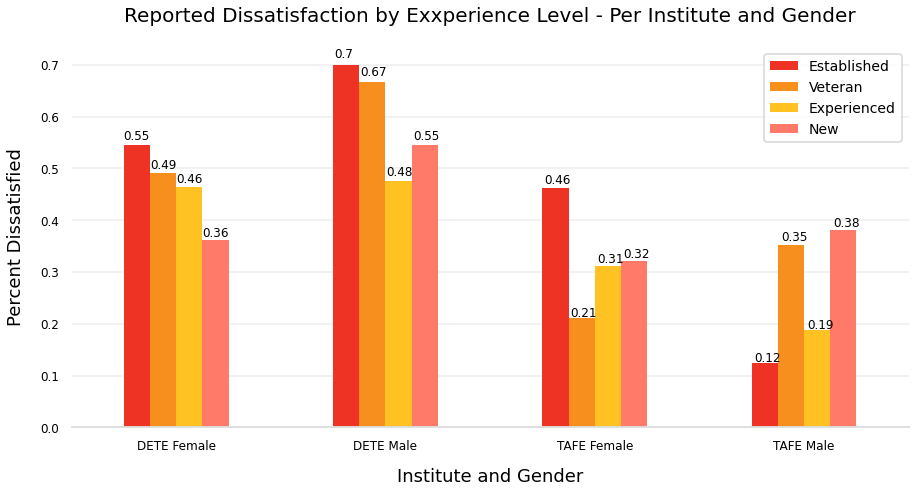

```python
sns.set_context('talk')
ax= df.plot(kind='bar',
             fontsize=12,
             rot=0,
             color=['#EE3224', '#F78F1E', '#FFC222', '#ff7a69'],figsize=(15,7))

ax.set_xticklabels([' '.join(i) for i in df.index])
plt.legend(fontsize=14)

# Axis styling.
ax.spines['top'].set_visible(False)
ax.spines['right'].set_visible(False)
ax.spines['left'].set_visible(False)
ax.spines['bottom'].set_color('#DDDDDD')
ax.tick_params(bottom=False, left=False,)
ax.set_axisbelow(True)
ax.yaxis.grid(True, color='#EEEEEE')
ax.xaxis.grid(False)

# Add axis and chart labels.
ax.set_xlabel('Institute and Gender', labelpad=15)
ax.set_ylabel('Percent Dissatisfied', labelpad=15)
ax.set_title(
    'Reported Dissatisfaction by Exxperience Level - Per Institute and Gender',
    size=20,
    pad=25)

#text annotations
for p in ax.patches:
    ax.annotate(str(round(p.get_height(), 2)),
                (p.get_x() * 1.005, p.get_height() * 1.02),
                fontsize=12)

plt.show()
```

# Conclusion

Further analysis should dive deeper into the reasons for high dissatisfaction levels for older and experience employees, in particular for male DETE employee and female TAFE employees. Lastly, the DETE institute should also investigate into why their reported overall level of dissatisfaction is much higher when compared to the TAFE institute.